# HW4

Dmitry Kharytonau

2023-03-30

dataset: GSM4407907 (Single-Cell RNA-Sequencing From Mouse Incisor Reveals Dental Epithelial Cell-Type Specific Genes) ## Importing libs and data

```r
library(Seurat)
library(Matrix)
library(MAST)
library(ggplot2)
library(dplyr)


data <- Read10X("./dara")
dim(data)
```

```
## [1] 48816  6260
```

```r
seurat <- CreateSeuratObject(data, min.cells = 313, min.features = 700)
dim(seurat)
```

```
## [1] 9423 6260
```

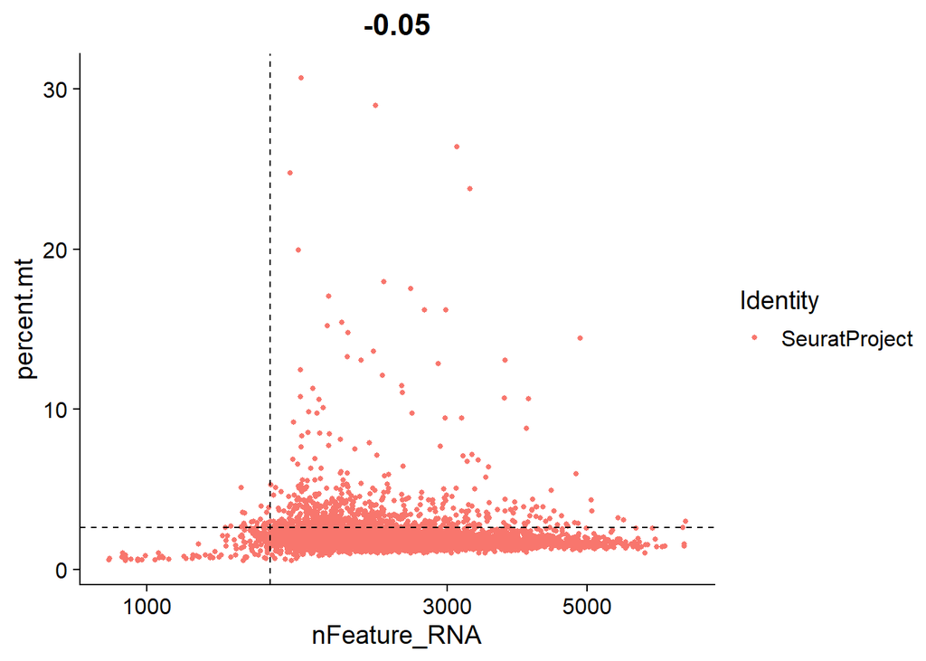

```r
seurat[["percent.mt"]] <- PercentageFeatureSet(seurat, pattern = "^mt-")

FeatureScatter(seurat, "nFeature_RNA", "percent.mt") + scale_x_log10() +
  geom_hline(yintercept = 2.6, lty=2) + geom_vline(xintercept = 1570, lty=2.5)
```

The lines there show the thrashholds which i have choosen

```r
seurat <- subset(seurat, subset = nFeature_RNA > 1570 & percent.mt < 2.6)
dim(seurat)
```

```
## [1] 9423 5461
```

I will use an ‘old school’ normalization sryle, becouse SCTransform() doesnt work properly on my (seems like latest) version of Seurat library. It does not clusterize cells well (This issue is also reported by other users on github)

## Normalization and visualization

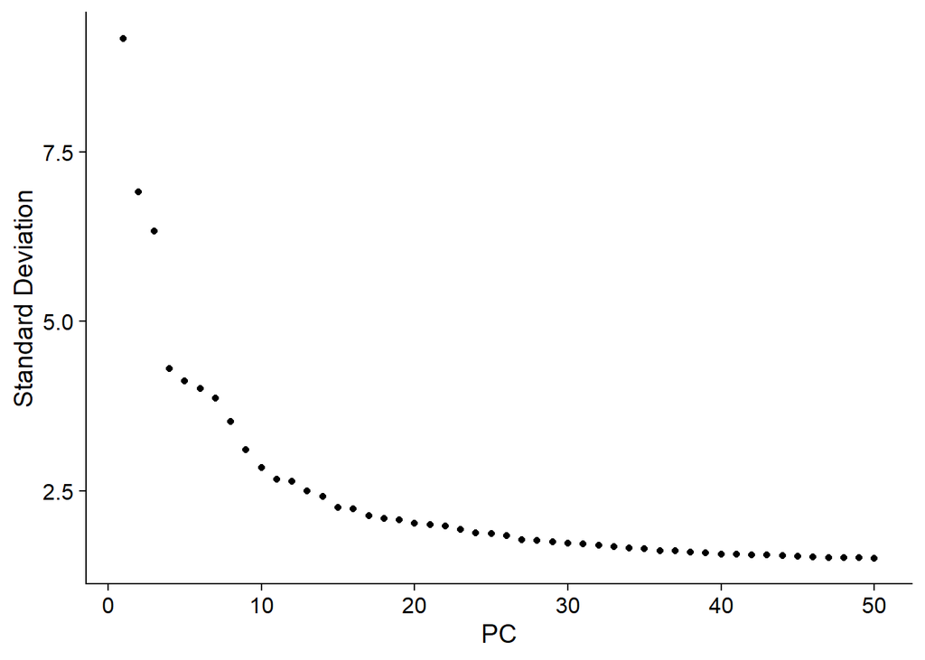

```r
seurat <- NormalizeData(seurat, normalization.method = "LogNormalize", scale.factor = 10000)
 seurat <- FindVariableFeatures(seurat, selection.method = "vst", nfeatures = 2000)
 seurat <- ScaleData(seurat)
seurat <- RunPCA(seurat)
ElbowPlot(seurat, ndims = 50)
```

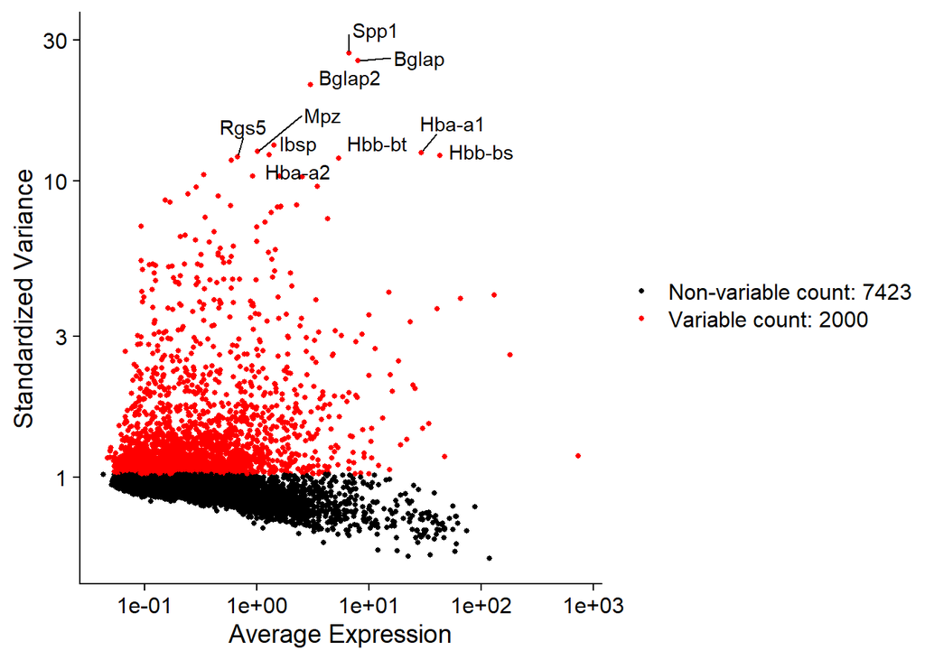

```r
top10_variable_genes <- head(VariableFeatures(seurat), 10)
VariableFeaturePlot(seurat) %>%
  LabelPoints(points = top10_variable_genes, repel = TRUE) +
  scale_y_log10()
```

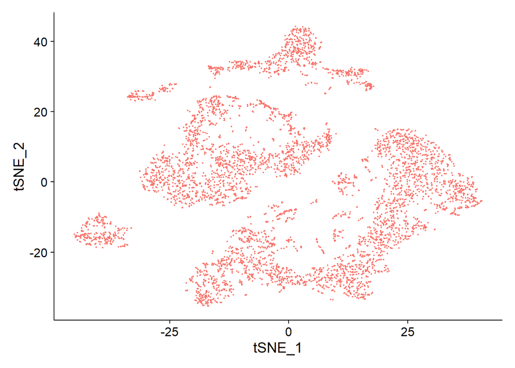

```r
seurat <- RunTSNE(seurat, dims=1:20)
DimPlot(seurat, reduction = "tsne") + NoLegend()
```

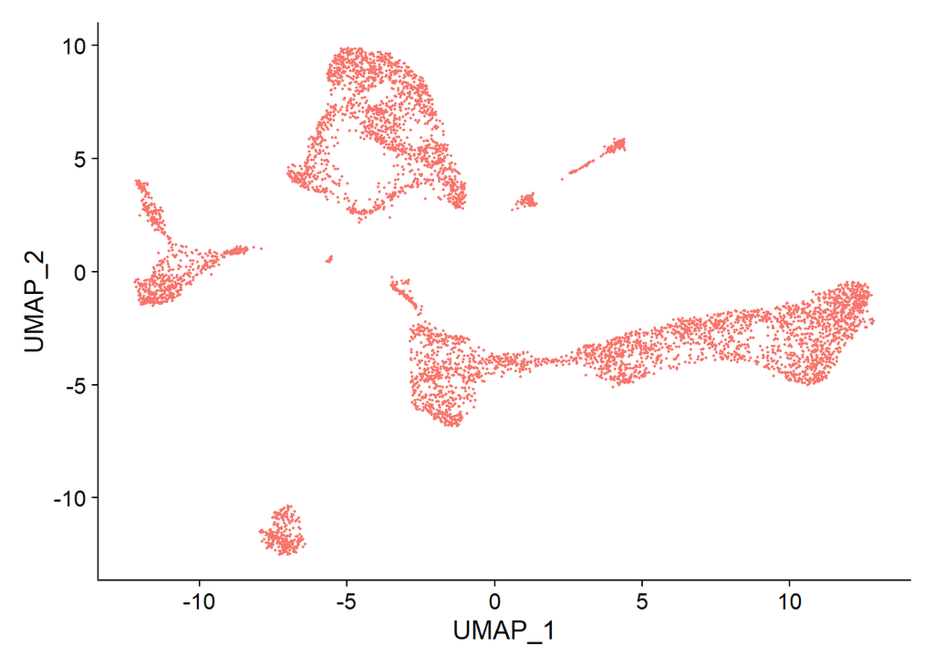

```r
seurat <- RunUMAP(seurat, dims=1:20)
DimPlot(seurat, reduction = "umap") + NoLegend()
```

## Clustering Now we will run clusterization. We will work with umap, because it looks more representative in our cese

```r
seurat <- FindNeighbors(seurat, dims = 1:20)
seurat <- FindClusters(seurat, resolution= 0.2)
```

```
## Modularity Optimizer version 1.3.0 by Ludo Waltman and Nees Jan van Eck
##
## Number of nodes: 5461
## Number of edges: 206040
##
## Running Louvain algorithm...
## Maximum modularity in 10 random starts: 0.9489
## Number of communities: 8
## Elapsed time: 0 seconds
```

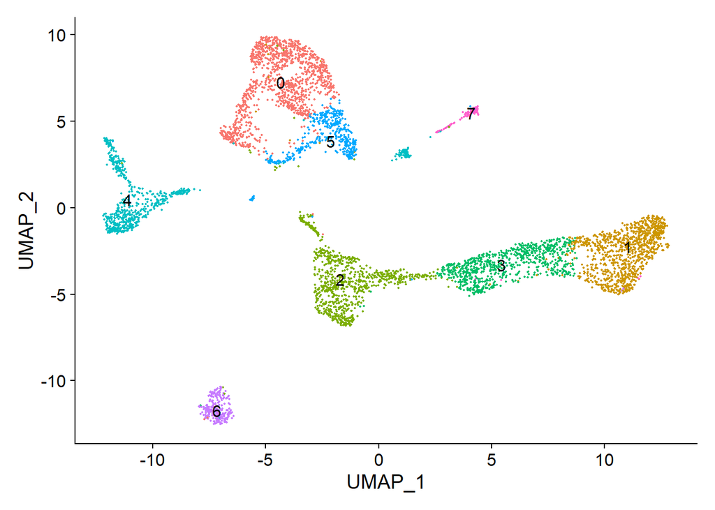

```r
DimPlot(seurat, reduction = "umap", label = TRUE) + NoLegend()
```

## Main cell types clusters

We will take markers from the articles and some other genes which were pointed like this cell types marker in literature and encrease the sugnificance of out research

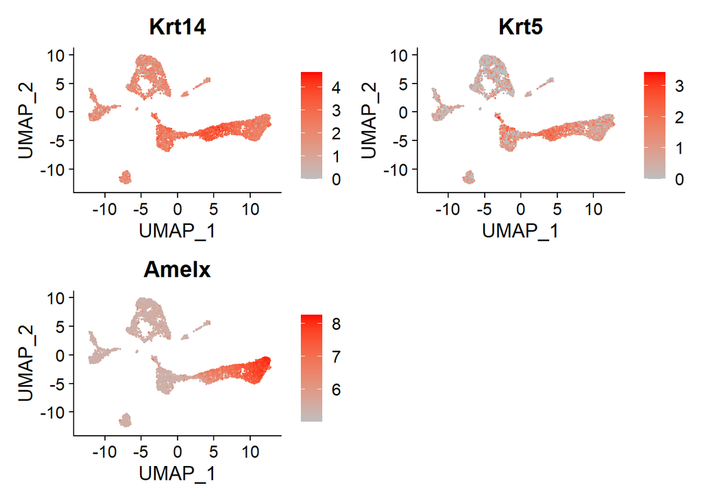

```r
## Dental endothelium
FeaturePlot(seurat, c("Krt14", "Krt5", "Amelx"), cols=c("grey", "red"), reduction="umap")
```

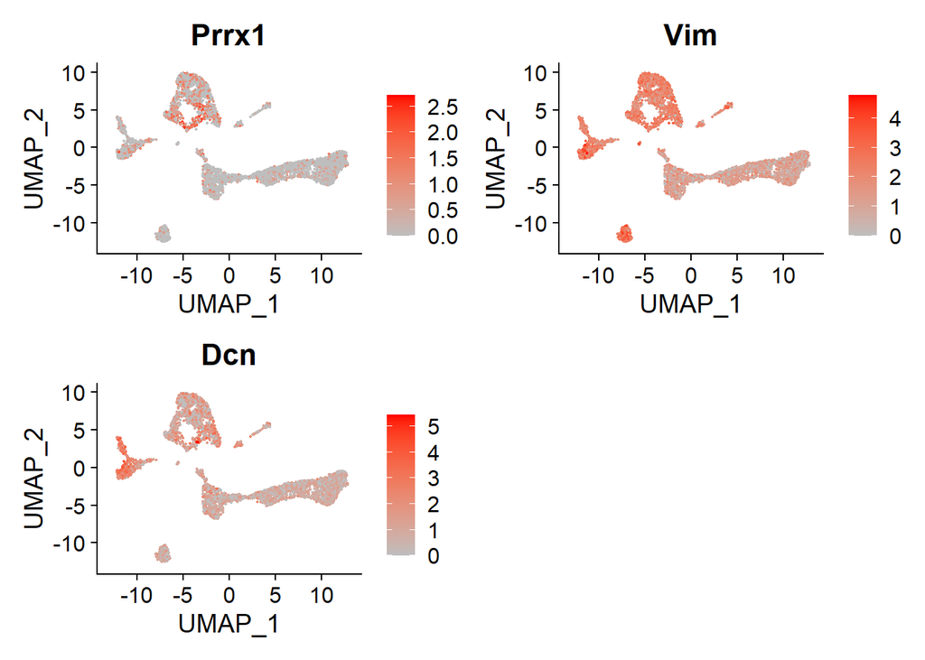

```r
## Mesenchyme
FeaturePlot(seurat, c("Prrx1", "Vim", "Dcn"), cols=c("grey", "red"), reduction="umap")
```

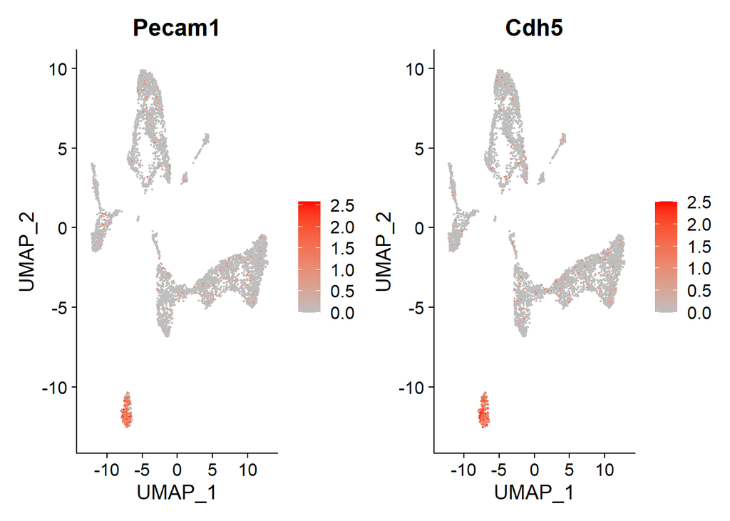

```r
## Endothelium
FeaturePlot(seurat, c("Pecam1", "Cdh5"), cols=c("grey", "red"), reduction="umap")
```

I have not included erythrosytes because they are not clearly seen in our plots. That is mostly due to more strict filtering settings.

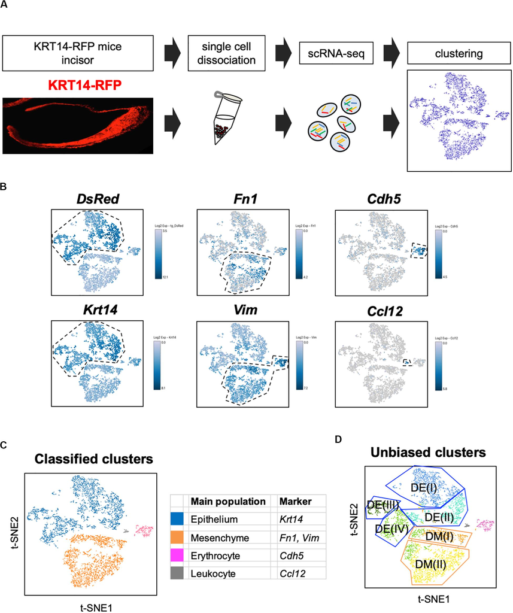

## Top differentially expressed genes

```r
 allMarkers <- FindAllMarkers(seurat, test.use = "MAST", only.pos = T)
goodMarkers <- allMarkers %>% group_by(cluster) %>% top_n(n = 1, wt = avg_log2FC) %>% pull(gene)
goodMarkers
```

```
## [1] "Nts"      "Ambn"     "Mt1"      "tg-DsRed" "Bglap"    "Spp1"     "Ccl21a"
## [8] "Apoe"
```

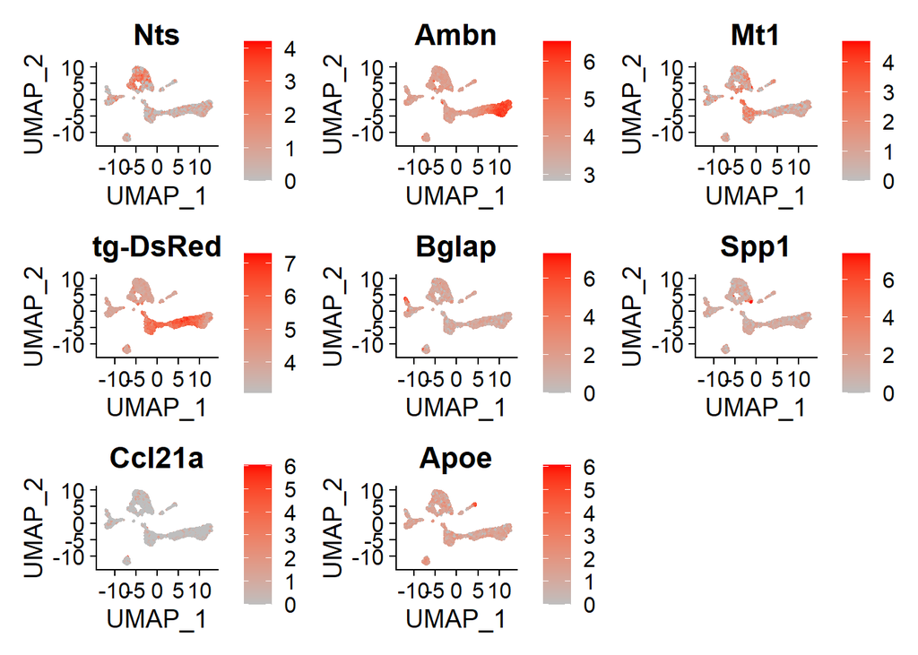

```r
FeaturePlot(seurat, goodMarkers[1:10], cols=c("grey", "red"), reduction="umap")
```

Our results partly corresponds to data given in the article (https://www.frontiersin.org/files/Articles/572726/fcell-08-00841-HTML/image_m/fcell-08-00841-t002.jpg). Table is too huge to paste it to the markdown. So, missmatches are, once again, are gererated by different thrashold choosen. In fact, we see the mane main cell populations like Ameloblasts, Odontoblasts and IEE/OEE cluster:

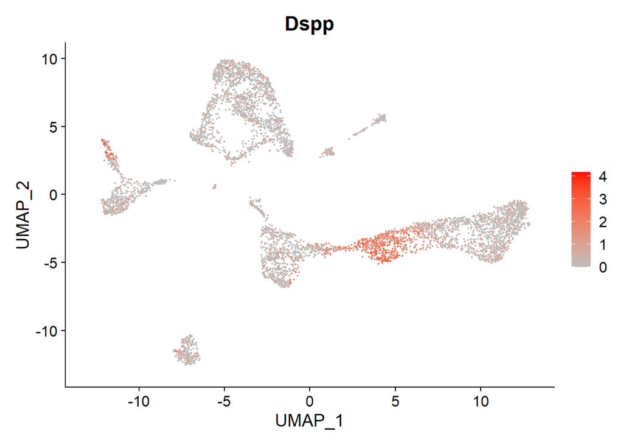

```r
#Ameloblasts
# Odontoblasts
FeaturePlot(seurat, c("Dspp"), cols=c("grey", "red"), reduction="umap")
```

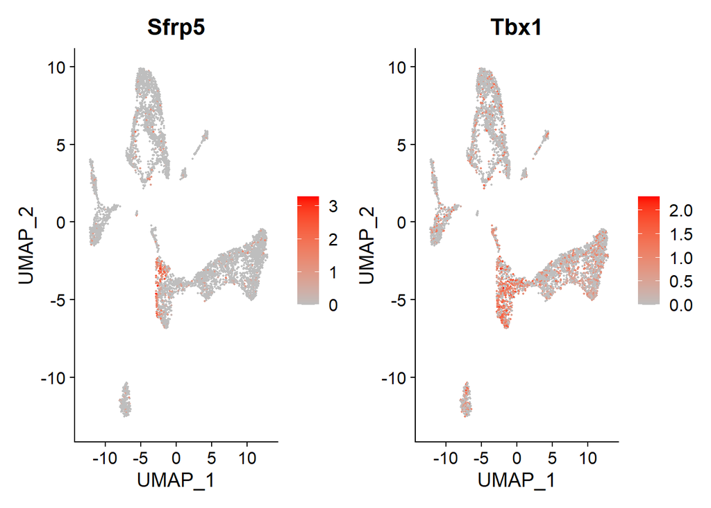

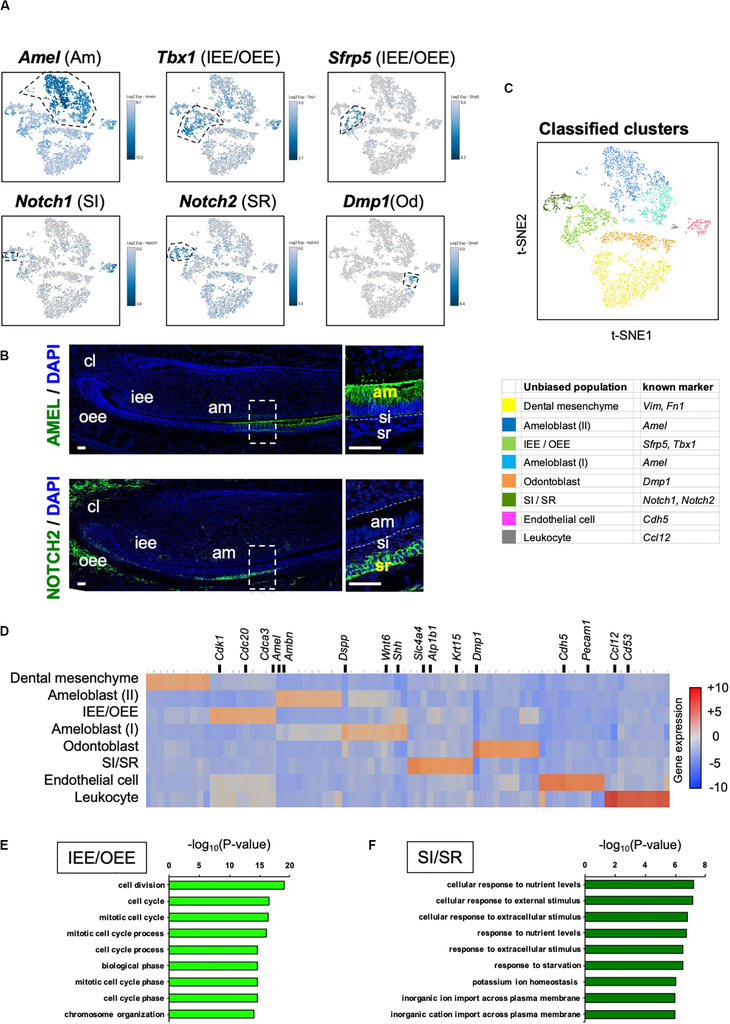

adittional cell types

```r
# IEE/OEE cluster
FeaturePlot(seurat, c("Sfrp5", "Tbx1"), cols=c("grey", "red"), reduction="umap")
```

and the cells mentioned above

## Violin plots

Violin plots are not represented in my article, but, as it was mentioned, main cell types and markers are overlapped. In fact, i know that you want to see some Vplots, so i will make them for our top DE markers

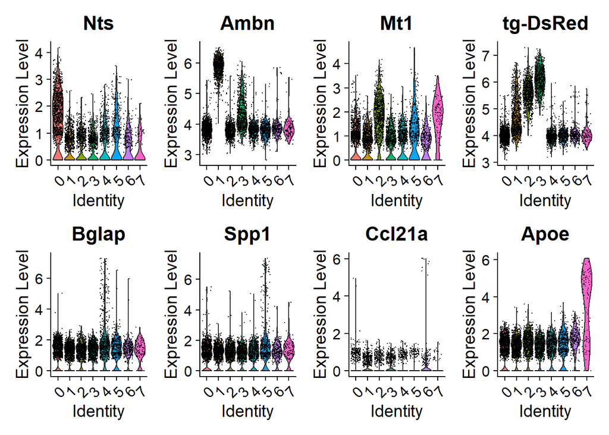

```r
VlnPlot(seurat, goodMarkers[1:10], pt.size = 0.1)
```